# ICE Detention Data FY21

Nathan Craig

15 Apr 2021

# 1 Introduction

This document represents exploratory data analysis of ICE’s Fiscal Year End Detention Reports. Currently, I am focusing on the FY21 dataset.

```r
library(sf)
library(ggplot2)
library(readxl)
library(tidyverse)
library(summarytools)
st_options(plain.ascii = FALSE,
           footnote = NA,
           subtitle.emphasis = FALSE,
           round.digits = 2)
library(knitr)
# knitr option that forces rounding
options(digits=3)
opts_chunk$set(results = 'asis',
               comment = NA,
               prompt = FALSE,
               cache = FALSE)
# knitr hook to put commas in the thousands place
# for inline numbers based on variables.
knit_hooks$set(inline = function(x) {
  prettyNum(x, big.mark=",")
})
```

## 1.1 Load Data

Data were downloaded from the [ICE Detention Management](https://www.ice.gov/detain/detention-management) webpage.

Based on facility address, coordinates were established using [Geocodio](https://www.geocod.io/), appended to the spreadsheet and converted to a shapefile. This work was done using ArcGIS.

```r
# Load Datasets
facilities <- st_read("./map_data/Facilities_FY21.shp")
states <- st_read("./map_data/cb_2018_us_state_500k.shp")
```

```r
# Rename Fields
facilities <- rename(facilities,
       `Accuracy Score` = Accuracy_S,
       `Accuracy Type` = Accuracy_T,
       `Zip Geocoded` = Zip_Geocod,
       `Type Detailed` = Type_Detai,
       `Male/Female` = Male_Femal,
       `Level A` = Level_A,
       `Level B` = Level_B,
       `Level C` = Level_C,
       `Level D` = Level_D,
       `Male Crim` = Male_Crim,
       `Male Non Crim` = Male_Non_C,
       `Female Crim` = Female_Cri,
       `Female Non Crim` = Female_Non,
       `ICE Threat Level 1` = ICE_Threat,
       `ICE Threat Level 2` = ICE_Thre_1,
       `ICE Threat Level 3` = ICE_Thre_2,
       `ICE No Threat Level` = No_ICE_Thr,
       `Mandatory Detention` = Mandatory,
       `Guaranteed Minimum (character)` = Guaranteed,
       `Guaranteed Minimum` = Guarante_1,
       `Last Inspection Type` = Last_Inspe,
       `Last Inspection Standard` = Last_Ins_1,
       `Last Inspection Rating - Final` = Last_Ins_2,
       `Last Inspection Date` = Last_Ins_3,
       `Second to Last Inspection Type` = Second_to,
       `Second to Last Inspection Standard` = Second_t_1,
       `Second to Last Inspection Rating` = Second_t_2,
       `Second to Last Insepction Date` = Second_t_3,
  ) %>%
  relocate(`Guaranteed Minimum`, .after = `Guaranteed Minimum (character)`) %>%
  select(-`Guaranteed Minimum (character)`)

# Convert Field Type
facilities$`Guaranteed Minimum` <- as.numeric(facilities$`Guaranteed Minimum`)
```

# 2 Summary Statistics

Calculate detention totals based on ICE’s reported data.

```r
facilities <- facilities %>%
  mutate(`Total Detained`=
           `Female Crim` +
           `Female Non Crim` +
           `Male Crim` +
           `Male Non Crim`) %>%
  mutate(`Total Males Detained` =
           `Male Crim` +
           `Male Non Crim`) %>%
  mutate(`Total Females Detained` =
           `Female Crim` +
           `Female Non Crim`) %>%
  mutate(`Percent No Threat` =
            (`ICE No Threat Level` /
           `Total Detained`)*100) %>%
  relocate(c(`Total Females Detained`,
             `Total Males Detained`,
             `Total Detained`,
             `Percent No Threat`), .after = `Guaranteed Minimum`)
```

List summary values

```r
facilities %>%
  select(c(-`Accuracy Score`, -Longitude, -Latitude, -Zip, -`Zip Geocoded`)) %>%
  descr(transpose = TRUE, stats = c("mean", "sd", "min", "med", "max"), headings = FALSE)
```

|  | Mean | Std.Dev | Min | Median | Max |
| --- | --- | --- | --- | --- | --- |
| Female Crim | 3.06 | 6.77 | 0 | 0.0 | 51 |
| Female Non Crim | 9.16 | 28.16 | 0 | 0.0 | 188 |
| FY21_ALOS | 65.13 | 67.91 | 0 | 53.0 | 379 |
| Guaranteed Minimum | 687.80 | 493.90 | 2 | 580.0 | 2400 |
| ICE No Threat Level | 54.14 | 87.18 | 0 | 14.0 | 513 |
| ICE Threat Level 1 | 31.68 | 45.52 | 0 | 14.0 | 276 |
| ICE Threat Level 2 | 12.04 | 16.02 | 0 | 6.0 | 98 |
| ICE Threat Level 3 | 11.46 | 15.73 | 0 | 6.0 | 94 |
| Level A | 45.77 | 84.26 | 0 | 9.0 | 507 |
| Level B | 16.75 | 26.20 | 0 | 6.5 | 156 |

[output cut: 9 more lines]

# 3 Facility Types

```r
# convert character vector to factor vector
facilities$`Type Detailed` <- as.factor(facilities$`Type Detailed`)

# confirm the type is correct
class(facilities$`Type Detailed`)
# table(facilities$`Type Detailed`)
```

```r
facilities %>%
  as_tibble() %>%
  count(`Type Detailed`)
```

| Type Detailed | n |
| --- | --- |
| BOP | 2 |
| CDF | 17 |
| IGSA | 73 |
| Other | 6 |
| SPC | 5 |
| USMS IGA | 39 |

```r
facility_types <- facilities %>%
  as_tibble() %>%
  count(`Type Detailed`) %>%
  mutate(`Percent Total` = prop.table(n)*100) %>%
  mutate_at(3, funs(round(.,2)))
facility_types %>%
  arrange(`Percent Total`)
```

| Type Detailed | n | Percent Total |
| --- | --- | --- |
| BOP | 2 | 1.41 |
| SPC | 5 | 3.52 |
| Other | 6 | 4.23 |
| CDF | 17 | 11.97 |
| USMS IGA | 39 | 27.46 |
| IGSA | 73 | 51.41 |

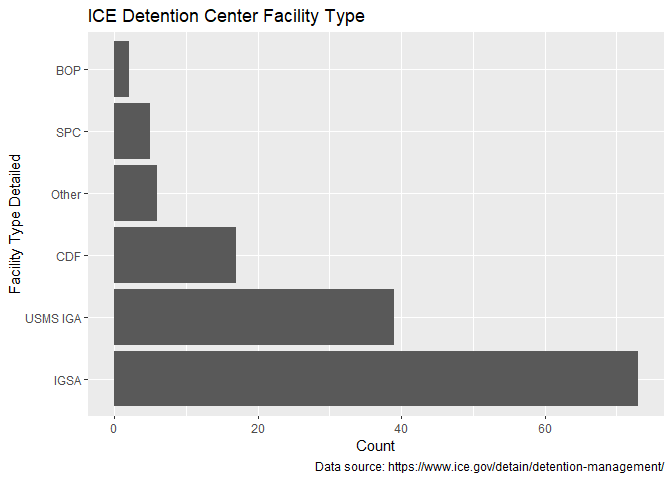

```r
ggplot(facilities, aes(y = fct_infreq(`Type Detailed`)))+
  geom_bar(stat = 'count')+
  ylab("Facility Type Detailed")+
  xlab("Count")+
  labs(
    title = "ICE Detention Center Facility Type",
    caption = "Data source: https://www.ice.gov/detain/detention-management/"
  )
```

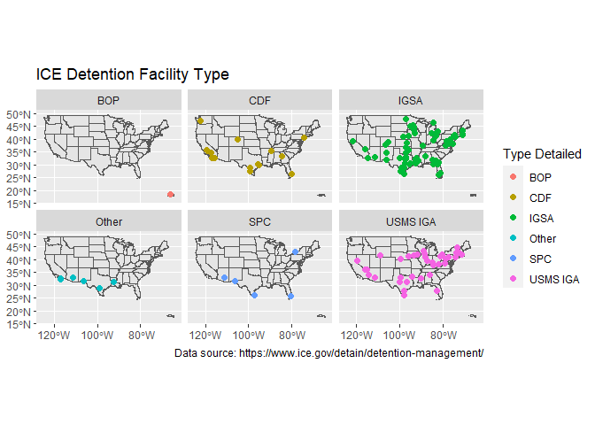

```r
ggplot()+
  geom_sf(data=states)+
  geom_sf(data=facilities, aes(color = `Type Detailed`), size = 2)+
  scale_shape_discrete(solid = FALSE)+
  coord_sf(xlim = c(-125,-64), ylim = c(16.5, 49.5), expand = TRUE)+
  scale_x_continuous(breaks = c(-120, -100, -80))+
  labs(
    title = "ICE Detention Facility Type",
    caption = "Data source: https://www.ice.gov/detain/detention-management/"
    )+
  facet_wrap(~`Type Detailed`, ncol =3)
```

## 3.1 Guaranteed Minimums

Of the 142 facilities listed in the FY21 ICE Detention Year End Report 35% (n = 50) have Guaranteed Minimums as part of their contracts. Based on data reported by ICE, there are a total of 34,390 guaranteed beds in FY21. The table below lists those facilities in descending order based on the Guaranteed Minimum number of beds stipulated in the contract.

```r
facilities %>%
  as_tibble() %>%
  select(c(Name, `Guaranteed Minimum`, `Total Detained`, `Mandatory Detention`, `Percent No Threat`)) %>%
  filter(`Guaranteed Minimum` >0) %>%
  arrange(desc(`Guaranteed Minimum`))
```

| Name | Guaranteed Minimum | Total Detained | Mandatory Detention | Percent No Threat |
| --- | --- | --- | --- | --- |
| South Texas Family Residential Center | 2400 | 299 | 155 | 99.33 |
| La Palma Correctional Center | 1800 | 428 | 248 | 77.57 |
| La Palma Correction Center - Apso | 1800 | 378 | 247 | 69.31 |
| Stewart Detention Center | 1600 | 673 | 526 | 30.61 |
| Adelanto ICE Processing Center | 1455 | 336 | 221 | 12.80 |
| South Texas ICE Processing Center | 1350 | 734 | 464 | 69.89 |
| Tacoma ICE Processing Center (Northwest Det Ctr) | 1181 | 311 | 248 | 16.40 |
| Lasalle ICE Processing Center (Jena) | 1170 | 464 | 344 | 55.17 |
| Otay Mesa Detention Center (San Diego Cdf) | 1100 | 352 | 227 | 53.98 |
| Adams County Det Center | 1100 | 348 | 318 | 65.80 |

[output cut: 40 more lines]

```r
aggregate(x = facilities$`Guaranteed Minimum`,
          by = list(facilities$`Type Detailed`),
          FUN = sum, na.rm=TRUE) %>%
  rename(`Type Detailed` = Group.1) %>%
  rename(`Total Guaranteed Minimum` = x)
```

| Type Detailed | Total Guaranteed Minimum |
| --- | --- |
| BOP | 0 |
| CDF | 10443 |
| IGSA | 21305 |
| Other | 0 |
| SPC | 2642 |
| USMS IGA | 0 |

## 3.2 Estimated number of “Ghost Beds”

Selman and Leighton (2010, 114) explain that compensation for private prisons is fraught with guarantees, including the payment of a minimum number of inmates which over time became standard language in many contracts. Selman and Leighton refer to the payment of nonexistent inmate beds through guaranteed minimums as “ghost inmates.” Immigration detention is modeled on corrections and is effectively punishment imposed through a program of prevention through deterrence. However, individuals incarcerated by ICE are held in what is supposed to be non-punitive civil custody. Therefore, rather than referring to empty guaranteed beds that are paid for through contractual obligations as “ghost inmates” I refer to these in the immigration context as “ghost beds.”

```r
ghost_beds <- facilities %>%
  select(c(Name, `Guaranteed Minimum`, `Total Detained`, `Percent No Threat`)) %>%
  filter(`Guaranteed Minimum` >0) %>%
  mutate(`Estimated Ghost Beds` = `Guaranteed Minimum` - `Total Detained`) %>%
  select(c(Name, `Estimated Ghost Beds`)) %>%
  arrange(desc(`Estimated Ghost Beds`))
```

Based on ICE data, for FY21 there are a total of 22,960 ghost beds. Assuming an average cost of $100 per day per bed, this comes out to $2,296,000 per day paid for empty detention beds.

```r
as_tibble(ghost_beds) %>%
  select(-geometry)
```

| Name | Estimated Ghost Beds |
| --- | --- |
| South Texas Family Residential Center | 2101 |
| La Palma Correction Center - Apso | 1422 |
| La Palma Correctional Center | 1372 |
| Adelanto ICE Processing Center | 1119 |
| Stewart Detention Center | 927 |
| Tacoma ICE Processing Center (Northwest Det Ctr) | 870 |
| Adams County Det Center | 752 |
| Otay Mesa Detention Center (San Diego Cdf) | 748 |
| Karnes County Residential Center | 718 |
| Lasalle ICE Processing Center (Jena) | 706 |

[output cut: 40 more lines]

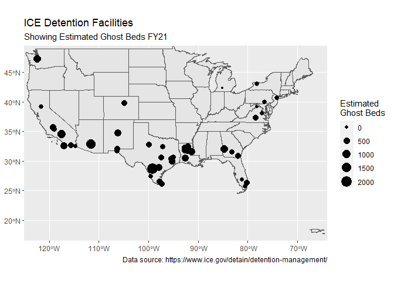

```r
ggplot()+
  geom_sf(data=states)+
  geom_sf(data=ghost_beds, aes(size=`Estimated Ghost Beds`))+
  coord_sf(xlim = c(-125,-64), ylim = c(16.5, 49.5), expand = FALSE)+
    labs(
    title = "ICE Detention Facilities",
    subtitle = "Showing Estimated Ghost Beds FY21",
    caption = "Data source: https://www.ice.gov/detain/detention-management/",
    size = "Estimated\nGhost Beds")
```

## 3.3 Threat Level

```r
no_threat <-
  facilities %>%
  select(c(Name, `Percent No Threat`, `Total Detained`)) %>%
  arrange(desc(`Percent No Threat`))
as_tibble(no_threat) %>%
  select(-geometry)
```

| Name | Percent No Threat | Total Detained |
| --- | --- | --- |
| Karnes County Residential Center | 100.00 | 112 |
| Cbp San Ysidro Poe | 100.00 | 2 |
| Madison County Jail | 100.00 | 1 |
| South Texas Family Residential Center | 99.33 | 299 |
| T. Don Hutto Detention Center | 98.59 | 71 |
| Cca, Florence Correctional Center | 85.71 | 84 |
| Cbp Chula Vista Bps | 84.62 | 13 |
| Allen Parish Public Safety Complex | 84.38 | 64 |
| El Valle Detention Facility | 83.49 | 327 |
| Clinton County Jail | 83.33 | 6 |

[output cut: 132 more lines]

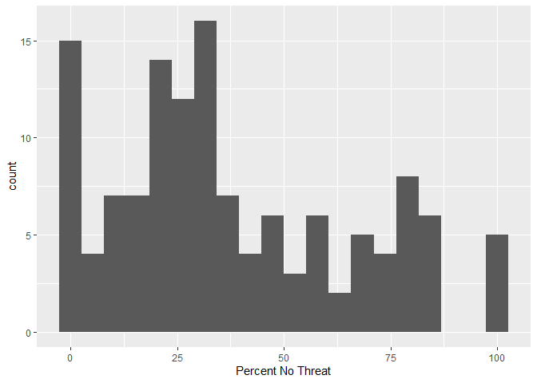

```r
no_threat %>%
ggplot()+
  geom_histogram(aes(`Percent No Threat`), bins = 20)
```

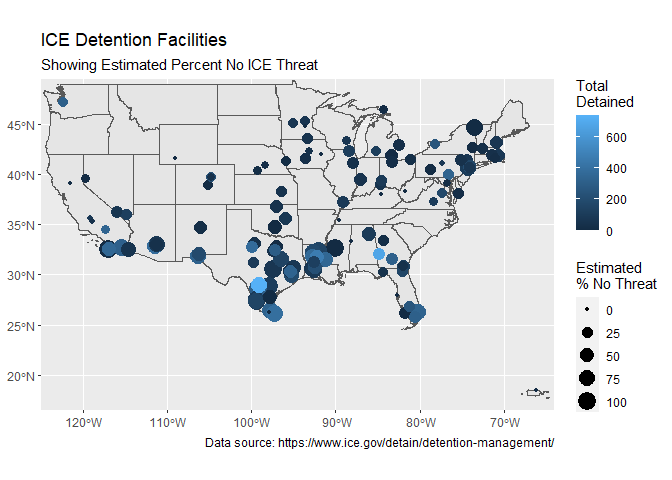

```r
ggplot()+
  geom_sf(data=states)+
  geom_sf(data=`no_threat`, aes(size=`Percent No Threat`, color=`Total Detained`))+
  coord_sf(xlim = c(-125,-64), ylim = c(16.5, 49.5), expand = FALSE)+
    labs(
    title = "ICE Detention Facilities",
    subtitle = "Showing Estimated Percent No ICE Threat",
    caption = "Data source: https://www.ice.gov/detain/detention-management/",
    color = "Total\nDetained",
    size = "Estimated\n% No Threat")
```

## 3.4 Mandatory Detention

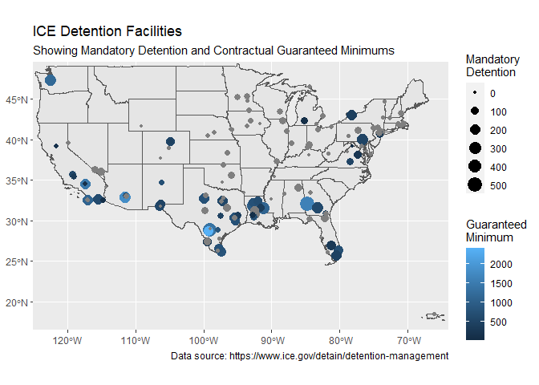

```r
ggplot()+
  geom_sf(data=states)+
  geom_sf(data=facilities, aes(color = `Guaranteed Minimum`, size = `Mandatory Detention`))+
  coord_sf(xlim = c(-125,-64), ylim = c(16.5, 49.5), expand = FALSE)+
  labs(
    title = "ICE Detention Facilities",
    subtitle = "Showing Mandatory Detention and Contractual Guaranteed Minimums",
    caption = "Data source: https://www.ice.gov/detain/detention-management",
    color ="Guaranteed\nMinimum",
    size = "Mandatory\nDetention")
```

# References

Selman, Donna, and Paul Leighton. 2010. *Punishment for Sale: Private Prisons, Big Business, and the Incarceration Binge*. Issues in Crime & Justice. Lanham, Md: Rowman & Littlefield Publishers.